# winwin text analysis

AJ Caughey

5/29/2020

```r
knitr::opts_chunk$set(echo = TRUE)
library(rvest)
library(magrittr)
library(data.table)
library(lubridate)
library(xml2)
library(purrr)
library(tidyr)
library(tidyverse)
library(ggthemes)
```

# Getting Started: Pulling Out the Data

First we need to load in our data, which is one page of search results.

```r
peoples_daily_archived_page <- "http://data.people.com.cn/rmrb/s?type=1&qs=%7B%22cds%22%3A%5B%7B%22cdr%22%3A%22AND%22%2C%22cds%22%3A%5B%7B%22fld%22%3A%22title%22%2C%22cdr%22%3A%22OR%22%2C%22hlt%22%3A%22true%22%2C%22vlr%22%3A%22AND%22%2C%22qtp%22%3A%22DEF%22%2C%22val%22%3A%22%E5%8F%8C%E8%B5%A2+%E5%8F%B0%E6%B9%BE%22%7D%2C%7B%22fld%22%3A%22subTitle%22%2C%22cdr%22%3A%22OR%22%2C%22hlt%22%3A%22false%22%2C%22vlr%22%3A%22AND%22%2C%22qtp%22%3A%22DEF%22%2C%22val%22%3A%22%E5%8F%8C%E8%B5%A2+%E5%8F%B0%E6%B9%BE%22%7D%2C%7B%22fld%22%3A%22introTitle%22%2C%22cdr%22%3A%22OR%22%2C%22hlt%22%3A%22false%22%2C%22vlr%22%3A%22AND%22%2C%22qtp%22%3A%22DEF%22%2C%22val%22%3A%22%E5%8F%8C%E8%B5%A2+%E5%8F%B0%E6%B9%BE%22%7D%5D%7D%5D%2C%22obs%22%3A%5B%7B%22fld%22%3A%22dataTime%22%2C%22drt%22%3A%22DESC%22%7D%5D%7D"

peoples_daily_archived <- read_html(peoples_daily_archived_page)
```

Now that we have our webpage, we can try and identify the nodes we are interested in.

Let’s just start with the article itself first. We’ll pull out the body nodes.

```r
str(peoples_daily_archived)
```

```
## List of 2
##  $ node:<externalptr>
##  $ doc :<externalptr>
##  - attr(*, "class")= chr [1:2] "xml_document" "xml_node"
```

```r
body_nodes <- peoples_daily_archived %>%
  html_node("body") %>%
  html_children()
```

We’re interested in getting the article headline text, dates, and the keyword tags associated with each article.

What’s the html code structure for each of those?

…

We can use xml_find_all to find all the div nodes in the body of the document that have a class name containing the class names we want. Luckily, extracting these is pretty easy, we just provide the class name.

```r
#three vectors for each variable we are interested in
dates <- peoples_daily_archived %>%
  html_nodes('body') %>%
  xml_find_all("//div[contains(@class, 'listinfo')]") %>%
  html_text()

key_word_tags <- peoples_daily_archived %>%
  html_nodes('body') %>%
  xml_find_all("//div[contains(@class, 'keywords')]") %>%
  html_text()

headline <- peoples_daily_archived %>%
  html_nodes('body') %>%
  xml_find_all("//a[contains(@class, 'open_detail_link')]") %>%
  html_text()
```

Great! Right now we have vectors for each different variable. Next, we’ll stitch them all into a data frame.

```r
peoples_daily_df <- data.frame(headline, dates, key_word_tags)
```

This works for one page, but it’d be better to have a function that automates all this work over all the search results.

The function below takes the URL as an argument and gives us a dataframe for headlines, dates, and keywords.

```r
get_article_keys_dates <- function(webpage = "url") {

  #progress indicator
  cat("scraped_")

  #get url from input and read html
  input <- read_html(webpage)

  #scrape data
  dates <- input %>%
  html_nodes('body') %>%
  xml_find_all("//div[contains(@class, 'listinfo')]") %>%
  html_text()

key_word_tags <- input %>%
  html_nodes('body') %>%
  xml_find_all("//div[contains(@class, 'keywords')]") %>%
  html_text

headline <- input %>%
  html_nodes('body') %>%
  xml_find_all("//a[contains(@class, 'open_detail_link')]") %>%
  html_text

#semi-randomized delay so we don't send too many requests
wait_time <- runif(1, .8, 10)
Sys.sleep(wait_time)

#create dataframe
peoples_daily_df <- data.frame(headline, dates, key_word_tags)

peoples_daily_df
}
```

Next, we iterate that function over all the pages for a search result. We can use lapply to create a list of dataframes with scraped text.

I could improve this by generalizing. If I scrape the first and last page numbers from the website, and put that in my function, I could maybe use that value to replace the manually entered digits. All the pages chop off the page No at the same spot, so then I’d just have to enter the URL for my search at that should work to generalize.

```r
#iterate over page functions

seperate_pages_as_df <- lapply(paste0("http://data.people.com.cn/rmrb/s?qs=%7B%22cds%22%3A%5B%7B%22cdr%22%3A%22AND%22%2C%22cds%22%3A%5B%7B%22fld%22%3A%22title%22%2C%22cdr%22%3A%22OR%22%2C%22hlt%22%3A%22true%22%2C%22vlr%22%3A%22OR%22%2C%22val%22%3A%22%E5%85%B1%E8%B5%A2%22%7D%2C%7B%22fld%22%3A%22subTitle%22%2C%22cdr%22%3A%22OR%22%2C%22hlt%22%3A%22true%22%2C%22vlr%22%3A%22OR%22%2C%22val%22%3A%22%E5%85%B1%E8%B5%A2%22%7D%2C%7B%22fld%22%3A%22introTitle%22%2C%22cdr%22%3A%22OR%22%2C%22hlt%22%3A%22true%22%2C%22vlr%22%3A%22OR%22%2C%22val%22%3A%22%E5%85%B1%E8%B5%A2%22%7D%5D%7D%5D%2C%22obs%22%3A%5B%7B%22fld%22%3A%22dataTime%22%2C%22drt%22%3A%22DESC%22%7D%5D%7D&tr=A&ss=1&pageNo=", 1:45),
                               #there are 45 pages of search results
       get_article_keys_dates)
```

```
## scraped_scraped_scraped_scraped_scraped_scraped_scraped_scraped_scraped_scraped_scraped_scraped_scraped_scraped_scraped_scraped_scraped_scraped_scraped_scraped_scraped_scraped_scraped_scraped_scraped_scraped_scraped_scraped_scraped_scraped_scraped_scraped_scraped_scraped_scraped_scraped_scraped_s…
```

```r
gongying_all <- bind_rows(seperate_pages_as_df)
```

# Cleaning Up Our Scraped Data

This is a good start, but the data is still pretty messy. We’ll need to take out some of the junk text in the key words variable, clean up the dates to make sure they are in a standard format, and drop the standard shared keyword tag.

It would also be helpful to create three separate columns for keywords 1, 2, and 3. Some of these will have NA values if there’s only one or two associated keywords with the article, but that’s fine.

Each keyword is separated by a space, so we’ll use this to our advantage.

```r
#cleaning out the /t and /r noise
gongying_all$dates <- str_squish(gongying_all$dates)
gongying_all$key_word_tags <- str_squish(gongying_all$key_word_tags)

#converting to ymd dates, no characters
  #remember single digit months/days have no empty 0 in front,
  #need optional values in substring

#example date: 2020年5月19日第3版 【浏览本版】

gongying_all$dates <- str_extract_all(gongying_all$dates,
                                      "\\d\\d\\d\\d.\\d?\\d.\\d?\\d") #just date

gongying_all$year <- str_extract_all(gongying_all$dates,
                                     "\\d\\d\\d\\d") %>% #year
  as.numeric()

gongying_all$day <- str_extract(string =  gongying_all$dates,
                                "\\d?\\d$") %>% #mday
  as.numeric()

gongying_all$month <- str_extract_all(gongying_all$dates,
                                      "\\d?\\d月")  %>%   #month
                                str_extract_all("\\d?\\d") %>%
                                      as.numeric()
gongying_all <- gongying_all %>%  #remove old column with characters
   select(-dates)

#stitch date back together, cleaned
gongying_all$date <- paste(gongying_all$year, gongying_all$month, gongying_all$day, sep = "-") %>%
           ymd() %>%
           as.Date()
```

We’ve cleaned dates, now we use some of the same tools to clean up keywords.

Remember, we want to make multiple columns for each key word. Keywords are seperated by spaces.

```r
#lets start by droping the junky tag at the beginning

#example entry      文章关键词： 合作 “一带一路” 塞尔维亚

gongying_all$test_keywords <- str_extract_all(gongying_all$key_word_tags,
                                              "[^文章关键词]")

gongying_all$key_word_tags <- str_remove_all(gongying_all$key_word_tags,
                                             "^.......")

#create new columns for each keyword
gongying_all<- gongying_all %>%
  separate(key_word_tags, c("tag_1", "tag_2", "tag_3"),
           sep = " ",
           remove = FALSE,
           extra = "warn",
           fill = "warn")
gongying_all <- gongying_all %>%          #drop columns we don't need anymore
  select(-key_word_tags, -test_keywords)

#last cleaning to standardize gongying with our function
gongying <- gongying_all %>%
  rename("years" = year)
```

```r
#save as a csv locally, which will be pushed to github
write_csv(gongying, "win_win_cleaned_data2.csv")

#read that document in, specify we have chinese characters with UTF encoding
gongying <- read.csv("win_win_cleaned_data2.csv", stringsAsFactors = FALSE,
          encoding = "UTF-8")
```

# Data Analysis (finally!)

## Analyzing Usage Over Time

Now we can start doing the actual analysis!

Let’s start by looking first at how usage of gongying has change over time.

After we get a sense of change over time, we can break it down and look at keywords.

A note about gongying - including both article text and headlines, there are only 13 mentions of this word from 1946 until 2000, thats out of 12919 results in total.

I’ll also plot they keyword usage over time.

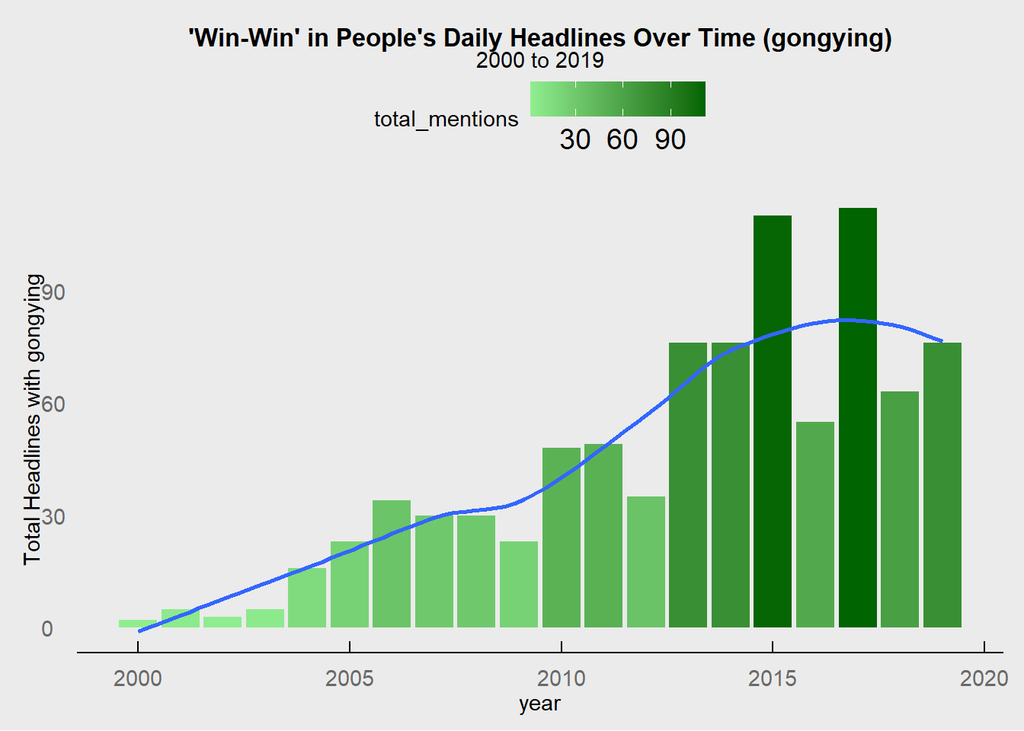

```r
#how has frequency of the term changed over time?


#gongying
gongying %>%
  group_by(years) %>%
  summarise(total_mentions = n()) %>%
  filter(years != "2020") %>%
  ggplot(aes(x = years, y = total_mentions, fill = total_mentions)) +
  geom_bar(stat = "identity") +
  scale_fill_gradient(low = "lightgreen", high = "darkgreen") +
  geom_smooth(se = FALSE) +
  labs(title = "'Win-Win' in People's Daily Headlines Over Time (gongying)",
       subtitle = "2000 to 2019") +
  xlab("year") +
  ylab("Total Headlines with gongying") +
   #build aesthetic style on existing theme
  theme_economist_white() +
  theme(
        #adjust title and subtitle position
        plot.title = element_text(hjust = .5, size = 12.5),
        plot.subtitle = element_text(hjust = .5, size = 11),
        #remove grid
        panel.grid.major = element_blank(), panel.grid.minor = element_blank(),
        #remove white background
        panel.background = element_blank(),
        #change caption, legend, axis text to gray text
        plot.caption = element_text(hjust = 1, vjust = -3,
                                    colour = "dimgray", size = 6.5),
        legend.position = ,
        axis.text.y = element_text(colour = "dimgray"),
        axis.text.x = element_text(color = "dimgray"),
        axis.title.x = element_text(vjust = -.8, color = "black"))
```

# Common Themes: Keyword Tag Analysis

What keywords are used most often in articles about gongying? We can use the article tags from the archive to get a better sense of this.

In the future, I could improve upon this code by creating a function and iterating that over the respective columns to cut down on copied text

```r
common_keys_1 <- gongying %>%
  group_by(tag_1) %>%
  summarise(count = n())
commong_keys_2 <- gongying %>%
  group_by(tag_2) %>%
  summarise(count = n())
common_keys_3 <- gongying %>%
  group_by(tag_3) %>%
  summarise(count = n())
#stiching each column together into one dataframe
key_word_totals <- full_join(common_keys_1, commong_keys_2, by = c("tag_1" = "tag_2")) %>%
  full_join(common_keys_3, by = c("tag_1" = "tag_3")) %>%
  #counting up usage all time, ignoring NAs
  mutate(count.x = ifelse(!is.na(count.x), count.x, 0),
         count.y = ifelse(!is.na(count.y), count.y, 0),
         count = ifelse(!is.na(count), count, 0),
         total_mentions = count.x + count.y + count,
        #ranking all time
         rank = rank(-total_mentions)) %>%
    rename("tag" = tag_1) %>%
  select(tag, total_mentions, rank) %>%
  arrange(desc(rank))
```

We have a sense of the most frequently used keywords for gongying, but we don’t know if usage of these keywords has changed over time.

We’ll modify our code slightly to group by years, and create a dataframe that counts usage by year.

```r
#keywords over time
common_keys_1_years <- gongying %>%
  group_by(tag_1, years) %>%
  summarise(count = n()) %>%
  mutate(id = str_c(tag_1, years))
commong_keys_2_years <- gongying %>%
  group_by(tag_2, years) %>%
  summarise(count = n()) %>%
  mutate(id = str_c(tag_2, years))
common_keys_3_years <- gongying %>%
  group_by(tag_3, years) %>%
  summarise(count = n()) %>%
  mutate(id = str_c(tag_3, years))
#stiching each column together into a dataframe
key_word_totals_yearly <- left_join(common_keys_1_years, commong_keys_2_years, by = "id")
key_word_totals_yearly <- left_join(key_word_totals_yearly, common_keys_3_years, by = "id") %>%
  #counting up usage per year, ignorning NAs
  mutate(count.x = ifelse(!is.na(count.x), count.x, 0),
         count.y = ifelse(!is.na(count.y), count.y, 0),
         count = ifelse(!is.na(count), count, 0),
         total_mentions = count.x + count.y + count,
         #ranking
         rank = as.integer(rank(-total_mentions))) %>%
    rename("tag" = tag_1, "year" = years.x) %>%
  select(tag, year, total_mentions, rank) %>%
  arrange(desc(total_mentions))
```

Currently, all our country names and keywords are in Chinese. To make this more legible for an English speaking audience, we’ll convert these to English below. Rather than translating every country, however, we’ll just do this for the most frequently mentioned terms and countries.

```r
#lets look at the top 20
common_keys <- key_word_totals %>%
  filter(!is.na(tag)) %>%
  filter(total_mentions >= 15)


#need english to show on ggplot
english_common_keys <- c(
"China",
"Dialogue",
"Adhere/Support",
"Shared Development",
"Culture",
"Initiative",
"Market",
"Peace",
"Investment",
"Innovation",
"International",
"Summit meeting",
"Sino-US relations",
"Business",
"Economy",
"Construct/Construction",
"win-win",
"Mutual benefit",
"Belt and Road",
"Cooperation") %>%
  as.data.frame()


common_keys <- english_common_keys %>%
  select('.') %>%
  cbind(common_keys) %>%
  rename("tag_english" = '.') %>%
  select(tag, tag_english, total_mentions, rank)


#common_keys <- cbind(common_keys, english_common_keys) %>%
#  rename("tag_english" = english_common_keys) %>%
#  select(tag, tag_english, total_mentions, rank)
```

## Plotting Commonly Used Keys

Now that we have our most commonly used keywords, lets visualize them to see what jumps out.

It will be easier to compare frequency for each term if we take our bar chart and flip it sideways, then arrange terms from most commonly used to least commonly used. I also add in a color gradient to make these differences more clear. Since all of the terms are commonly used, I use green for each (implying they are all frequently used), but just scale the green color to make the difference in popularity more apparent.

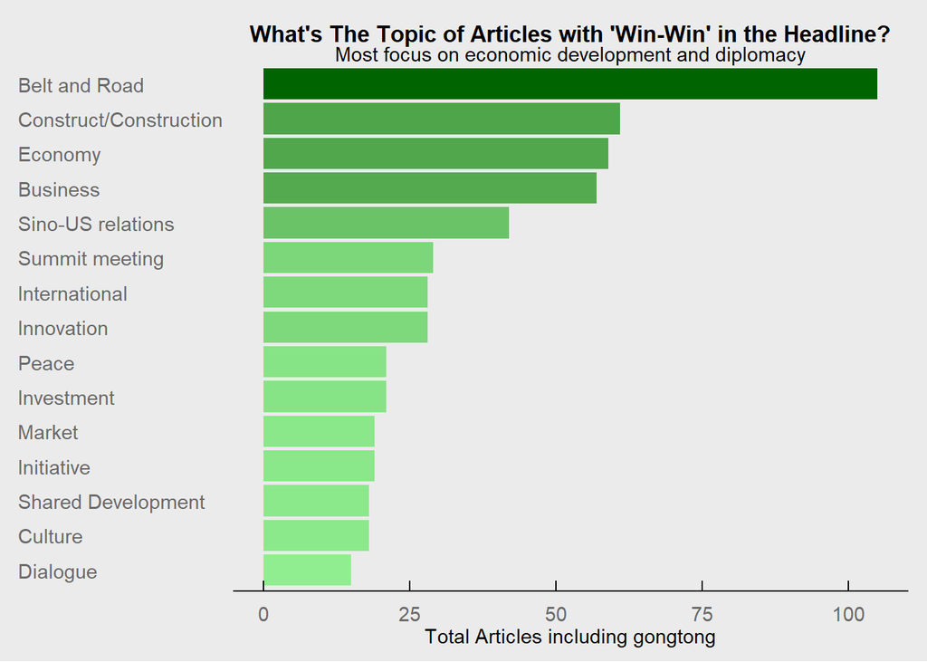

```r
common_topics_plot <- common_keys %>%
  filter(tag_english != "China" , tag_english != "Adhere/Support" ,
         tag_english != "win-win" , tag_english != "Cooperation",
         tag_english != "Mutual benefit") %>%
  ggplot(aes(x = reorder(tag_english, total_mentions), y = total_mentions,
             fill = total_mentions)) +
  geom_bar(stat = "identity") +
  #easy to compare vertically in descending order
  coord_flip() +
  #set color gradient manually to better fit
  scale_fill_gradient(low = "lightgreen", high = "darkgreen") +
   #clean up labels, more legible
  labs(title = "What's The Topic of Articles with 'Win-Win' in the Headline?",
       subtitle = "Most focus on economic development and diplomacy") +
  xlab("Article Keyword Topic") +
  ylab("Total Articles including gongtong") +
 #build aesthetic style on existing theme
  theme_economist_white() +
  theme(
        #adjust title and subtitle position
        plot.title = element_text(hjust = .5, size = 12.5),
        plot.subtitle = element_text(hjust = .5, size = 11),
        #remove grid
        panel.grid.major = element_blank(), panel.grid.minor = element_blank(),
        #remove white background
        panel.background = element_blank(),
        #change caption, legend, axis text to gray text
        plot.caption = element_text(hjust = 1, vjust = -3,
                                    colour = "dimgray", size = 6.5),
        legend.text = element_text(colour = "dimgray"),
        axis.text.y = element_text(colour = "dimgray"),
        axis.text.x = element_text(color = "dimgray"),
        axis.title.x = element_text(vjust = -.8, color = "black"),
        #remove axis line and fill color legend
        axis.line.y = element_blank(),
        axis.title.y = element_blank(),
        legend.position = "none")

  common_topics_plot
```

The chart above is useful, it tells us what topics win-win is generally applied to.

However, what if we want to see how the most common topics usage changed over time? This is easier to visualize with geom_line. We’ll look at just the most frequently used terms here.

It’s clear that Belt and Road came to dominate over time, perhaps subsuming the more general “business” and “economy” categories. In line with the larger trends, we see that usage dropped off in 2018, but has quite quickly rebounded.

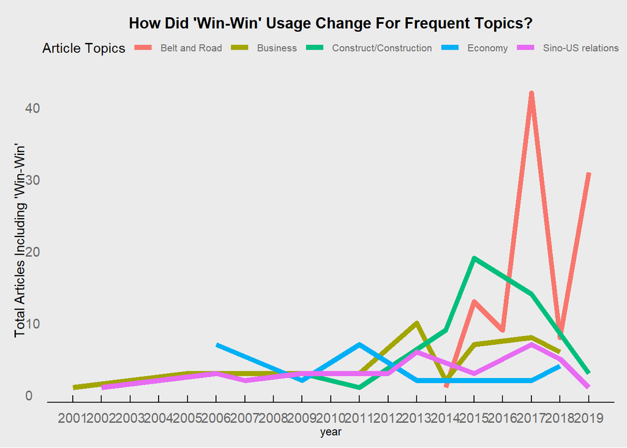

```r
#get our common keys in English
english_common_keys <- common_keys %>%
  select(tag, tag_english)

#join with English translation, and keep only most commonly used
important_keys_over_time <- left_join(key_word_totals_yearly,
                                      english_common_keys, by = "tag") %>%
  select(tag, tag_english, year, total_mentions) %>%
  filter(tag_english == "Belt and Road" |
           tag_english == "Construct/Construction" |
         tag_english == "Economy" |
           tag_english == "Sino-US relations" |
           tag_english == "Business") %>%
#exclude current year
  filter(year != "2020")

#create the plot
important_topics_yearly <- ggplot(important_keys_over_time,
                                  (aes(x=year, y=total_mentions,
                                       color = tag_english))) +
  geom_line(size = 2) +
  #clean up labels, more legible
  labs(title = "How Did 'Win-Win' Usage Change For Frequent Topics?",
       color = "Article Topics") +
  xlab("year") +
  ylab("Total Articles Including 'Win-Win'") +
  #change our scale so each year is shown
  scale_x_continuous(breaks = seq(2000, 2020, 1)) +
 #build aesthetic style on existing theme
  theme_economist_white() +
  theme(
        #adjust title and subtitle position
        plot.title = element_text(hjust = .5, size = 12.5),
        plot.subtitle = element_text(hjust = .5, size = 11),
        #remove grid
        panel.grid.major = element_blank(), panel.grid.minor = element_blank(),
        #remove white background
        panel.background = element_blank(),
        #change caption, legend, axis text to gray text
        plot.caption = element_text(hjust = 1, vjust = -3,
                                    colour = "dimgray", size = 6.5),
        legend.text = element_text(colour = "dimgray", size = 8),
        axis.text.y = element_text(colour = "dimgray"),
        axis.text.x = element_text(color = "dimgray"),
        axis.title.x = element_text(vjust = -.8, color = "black", size = 9))

important_topics_yearly
```

# Understanding “win-win” Usage by Country

We have a better understanding of how win-win rhetoric has been applied to specific thems over time, but what countries is it most commonly associated with? In other words, where in the world is this term being frequently used?

Further, are key terms and themes more commonly used in some countries than others?

Let’s start to answer those questions.

## Cleaning for Country Analysis

It’s clear that many of the keywords are actually bilaterial relationship or regional relationships. That’s pretty interesting and worth further exploration.

Where is “win-win” cooperation most often mentioned?

If we clean the data a little bit more, we can start to answer this question. We’ll need to extract the country name from the keyword tag using a regular expression, and then count up how many times each country is mentioned across columns.

Again, if we just slightly modify our previous code, we can count these mentions pretty easily. In the future, though, it’d be better to write a generalized function that cuts down on copy pasted text.

```r
#this section removes anything before guanxi
#most of these entries are bilateral relations witha  country. if we include them as a new category
#how does the data change?

#new dataframe to work with this question so I don't mess previous df up
gongying_bilat <- gongying

gongying_bilat$tag_1 <- str_replace(gongying$tag_1, "中.*关系$", "关系")
gongying_bilat$tag_2 <- str_replace(gongying$tag_2, "中.*关系$", "关系")
gongying_bilat$tag_3 <- str_replace(gongying$tag_3, "中.*关系$", "关系")

#make vectors that count mentions over time
#create a unique id to facilitate joining later

common_keys_1_years_bilat <- gongying_bilat %>%
  group_by(tag_1, years) %>%
  summarise(count = n()) %>%
  #create the id
  mutate(id = str_c(tag_1, years))
commong_keys_2_years_bilat <- gongying_bilat %>%
  group_by(tag_2, years) %>%
  summarise(count = n()) %>%
  mutate(id = str_c(tag_2, years))
common_keys_3_years_bilat <- gongying_bilat %>%
  group_by(tag_3, years) %>%
  summarise(count = n()) %>%
  mutate(id = str_c(tag_3, years))
#totals all time
key_word_totals_bilat <- full_join(common_keys_1, commong_keys_2,
                                   by = c("tag_1" = "tag_2")) %>%
  full_join(common_keys_3, by = c("tag_1" = "tag_3")) %>% #join all three together
  #count mentions across columns
  mutate(count.x = ifelse(!is.na(count.x), count.x, 0),
         count.y = ifelse(!is.na(count.y), count.y, 0),
         count = ifelse(!is.na(count), count, 0),
         total_mentions = count.x + count.y + count,
         #rank most mentioned countries
         rank = rank(-total_mentions)) %>%
    rename("tag" = tag_1) %>%
  select(tag, total_mentions) %>%
  #rearrange with key variables only
  arrange(desc(total_mentions))

#yearly totals over time
key_word_totals_yearly_bilat <- left_join(common_keys_1_years_bilat,
                                          commong_keys_2_years_bilat,
                                          by = "id") %>%
  left_join(common_keys_3_years_bilat, by = "id") %>%
  mutate(count.x = ifelse(!is.na(count.x), count.x, 0),
         count.y = ifelse(!is.na(count.y), count.y, 0),
         count = ifelse(!is.na(count), count, 0),
         total_mentions = count.x + count.y + count,
         rank = as.integer(rank(-total_mentions))) %>%
    rename("tag" = tag_1, year = years.x) %>%
  select(tag, years, total_mentions, rank) %>%
  arrange(desc(total_mentions))
```

Our data is still in Chinese and doesn’t have an English translation for readers. I’ll again take the most frequently used countries and provide an English translation.

```r
#creating larger group for africa
key_word_totals_bilat_africa <- key_word_totals_bilat

key_word_totals_bilat_africa$tag <- str_replace(key_word_totals_bilat$tag, ".*中非.*", "中非关系")

africa_total_mentions <- key_word_totals_bilat_africa %>%
  summarise(total_mentions = sum(ifelse(tag == "中非关系", total_mentions, 0), na.rm = TRUE)) %>%
  mutate(tag = "中非关系") %>%
  select(tag, total_mentions)

key_word_totals_bilat_africa$tag <- str_replace(key_word_totals_bilat$tag, ".*中非.*", "africa")


bilat_africa_country_summary <- key_word_totals_bilat_africa %>%
  filter(str_detect(tag, '关系')) %>%
  rbind(africa_total_mentions)

english_country_keys <- c(
  "US",
"Germany",
"International relations",
"India",
"France",
"Japan",
"Kazakhstan",
"Latin America",
"Korea",
"Arab",
"Russian",
"Pakistan",
"Europe",
"Myanmar",
"Zambia",
"Greece",
"Switzerland",
"Sino-Vietnamese",
"Nepal",
"Romania",
"Great powers",
"West",
"South Africa",
"Economic relations",
"Cross-Strait Economy",
"Rwanda",
"EU",
"Poland",
"Soviet",
"Partnerships",
"Croatia",
"Cyprus",
"Cambodia",
"Australia",
"Belarus",
"Jordan",
"Mozambique",
"Mexico",
"Strategic partnership",
"Political",
"Kyrgyzstan",
"Buddhist",
"Austria",
"Victoria",
"Singapore",
"Thailand",
"Finland",
"Mongolia",
"Africa")
```

## Visualizing Win-Win Usage by Country

With cleaned data and English translations, we’re ready to show how usage varies by country. We’ll start by inspecting the total mentions in the most common countries for all-time.

[figure not shown]

```r
bilat_africa_country_summary <- cbind(bilat_africa_country_summary, english_country_keys) %>%
    rename("tag_english" = english_country_keys) %>%
  select(tag, tag_english, total_mentions)

#plot data

bilat_summary_plot <- bilat_africa_country_summary  %>%
  filter(total_mentions >= 5, tag_english != "International relations") %>%
  ggplot(aes(x = reorder(tag_english, total_mentions), y = total_mentions,
             fill = total_mentions)) +
  geom_bar(stat = "identity") +
  coord_flip() +
  #set color gradient manually to better fit
  scale_fill_gradient(low = "lightgreen", high = "darkgreen") +
  #intuitive labels/titles
  labs(title = "What International Relationships Are 'Win-Win' Headlines About?") +
  xlab("Bilaterial Relationships") +
  ylab("Total Articles Including 'Win-Win' gongtong") +
  theme(axis.text.x=element_text(angle = -90, hjust = .05)) +
  #build aesthetic style on existing theme
  theme_economist_white() +
  theme(
        #adjust title and subtitle position
        plot.title = element_text(hjust = .5, size = 12.5),
        plot.subtitle = element_text(hjust = .5, size = 11),
        #remove grid
        panel.grid.major = element_blank(), panel.grid.minor = element_blank(),
        #remove white background
        panel.background = element_blank(),
        #change caption, legend, axis text to gray text
        plot.caption = element_text(hjust = 1, vjust = -3,
                                    colour = "dimgray", size = 6.5),
        legend.text = element_text(colour = "dimgray"),
        axis.text.y = element_text(colour = "dimgray"),
        axis.text.x = element_text(color = "dimgray"),
        axis.title.x = element_text(vjust = -.8, color = "black"),
        #remove axis line and fill color legend
        axis.line.y = element_blank(),
        axis.title.y = element_blank(),
        legend.position = )

bilat_summary_plot
```

Though we now know where win-win rhetoric is frequently used, we’d like to know more about what kinds of policies are being discussed as potential “win-wins”. Given that the Belt and Road is such a focal point for “win-win” coverage, it seems likely that non-BRI countries are discussed in the same language as BRI countries. How, then, does the coverage of Sino-African relations differ from, say, Japan and Germany?

To get a sense of this, we’ll need to find articles tagged with either Japan, Germany, or Africa, and then group by country and find the most commonly discussed topics mentioned for each country/region. There’s likeley to be some differences between the two.

In the future, I could improve on this by creating a bucket that includes all African countries alongside the “Sino-African Relations” tag that’s used by the archive. For now, though, this works as a good first-cut.

```r
#new dataframe with africa relationships recoded
gongying_dev_country <- gongying
gongying_dev_country$tag_1 <- str_replace(gongying$tag_1, ".*中非.*", "中非关系")
gongying_dev_country$tag_2 <- str_replace(gongying$tag_2, ".*中非.*", "中非关系")
gongying_dev_country$tag_3 <- str_replace(gongying$tag_3, ".*中非.*", "中非关系")

#mutate for binary variables indicating region of interest
#we need to look across all three columns for the country tag
germany_japan_africa <- gongying_dev_country %>%
  mutate(country =
           #articles focused on Germany
           ifelse(str_detect(gongying_dev_country$tag_1,
                             pattern = "中德关系") == TRUE,
                                "Germany",
                          ifelse(str_detect(gongying_dev_country$tag_2,
                                            pattern = "中德关系") == TRUE,
                                "Germany",
                                ifelse(str_detect(gongying_dev_country$tag_3,
                                                  pattern = "中德关系") == TRUE,
                                "Germany", 0))),
         #articles on Japan
         country = ifelse(str_detect(gongying_dev_country$tag_1,
                                     pattern = "中日关系") == TRUE,
                                "Japan",
                          ifelse(str_detect(gongying_dev_country$tag_2,
                                            pattern = "中日关系") == TRUE,
                                "Japan",
                                ifelse(str_detect(gongying_dev_country$tag_3,
                                                  pattern = "中日关系") == TRUE,
                               "Japan", country))),
         #articles on Africa
         country = ifelse(str_detect(gongying_dev_country$tag_1,
                                     pattern = "中非关系") == TRUE,
                                "Africa",
                          ifelse(str_detect(gongying_dev_country$tag_2,
                                            pattern = "中非关系") == TRUE,
                                "Africa",
                                ifelse(str_detect(gongying_dev_country$tag_3,
                                                  pattern = "中非关系") == TRUE,
                               "Africa", country)))) %>%
  filter(!is.na(country), country != "0")

#we create a summary for each column of keywords
gja_common_topics_1 <- germany_japan_africa %>%
  group_by(country, tag_1) %>%
  summarise(count = n())
gja_common_topics_2 <- germany_japan_africa %>%
  group_by(country, tag_2) %>%
  summarise(count = n())
gja_common_topics_3 <- germany_japan_africa %>%
  group_by(country, tag_3) %>%
  summarise(count = n())
#join those three summary columns together, and create ranked totals for all time
gja_topics_totals <- full_join(gja_common_topics_1, gja_common_topics_2,
                               by = c("country", "tag_1" = "tag_2")) %>%
  full_join(gja_common_topics_3, by = c("country", "tag_1" = "tag_3")) %>%
  #counting mentions across each column
   mutate(count.x = ifelse(!is.na(count.x), count.x, 0),
         count.y = ifelse(!is.na(count.y), count.y, 0),
         count = ifelse(!is.na(count), count, 0),
         total_mentions = count.x + count.y + count,
  #ranking key variables and arranging in descending order
         rank = rank(-total_mentions)) %>%
    rename("tag" = tag_1) %>%
  select(country, tag, total_mentions, rank) %>%
  arrange(country, rank)
```

These keywords are all still in Chinese, so once again we’ll take the most frequently mentioned topics in each region and translate them into English.

```r
#we need an english key to graph this, lets get all unique tags first

gja_tag_english <- c(
"China-Africa relations",
"Win-Win",
"Develop together",
"Friendship",
"Mutual benefit",
"China",
"Business",
"Community of Destiny",
"Neocolonialism",
"Access",
"Commentator",
"Africa-China Cooperation",
"Policy",
"Economy",
"Economic and Trade Cooperation",
"Condemn",
"Sino-German relations",
"Cooperation",
"Business",
"Mutual benefit",
"Make a big cooperation cake",
"Chinese Dream",
"win-win",
"Innovation",
"Friendship",
"Preh Automotive Company",
"Investment",
"EU",
"China-Japan Relationship",
"Cooperation",
"Exchange",
"Expand Reopening",
"China Korea Relationship",
"Mutual benefit",
"Meeting",
"win-win",
"Dialouge")
```

```r
#add english to dataframe
gja_topics_totals_english <- gja_topics_totals %>%
  cbind(gja_tag_english) %>%
  #clean up names
  rename("tag_english" = '...5') %>%
  #keep only what we need
  select(country, tag, total_mentions, rank, tag_english)
```

## Visualizing “win-win” policy areas in Germany, Japan, and Africa

```r
#plotting
gja_topics_plot <-  gja_topics_totals_english  %>%
  #filter out redundant synonyms or little-used phrases
 filter(tag_english != "China-Africa relations",
        tag_english != "Sino-German relations",
        tag_english != "China-Japan Relationship",
        tag_english!= "win-win",
        tag_english != "Mutual benefit",
        tag_english != "Policy",
        tag_english != "Make a big cooperation cake",
        tag_english != "EU",
        tag_english != "China",
        tag_english != "Africa-China Cooperation",
        tag_english != "China dream",
        tag_english != "Commentator",
        tag_english != "Cooperation") %>%
  #combine economy and trade into a common tag
  mutate(tag = ifelse(tag == "经济", "经贸合作", tag),
         tag_english = ifelse(tag == "经贸合作",
                              "Economic and Trade Cooperation",
                              tag_english))
#begin plotting
gja_topics_plot <- gja_topics_plot %>%
  ggplot(aes(x = reorder(tag_english, total_mentions), y = total_mentions,
             fill = total_mentions)) +
  geom_bar(stat = "identity") +
  facet_grid(~country) +
  coord_flip() +
  #set color gradient manually to better fit
  scale_fill_gradient(low = "lightgreen", high = "darkgreen") +
  #intuitive labels/titles
  labs(title = "How do Win-Win Article Key Topics Differ for Germany, Japan, and Africa?", subtitle =
         "Developmental With Africa, Businesswith Germany, Dialouge with Japan") +
  xlab("Tagged Topic") +
  ylab("Total Keywords Paired with Region") +
  theme_economist_white() +
  theme(
        #adjust title and subtitle position
        plot.title = element_text(hjust = .5, size = 10),
        plot.subtitle = element_text(hjust = .5, size = 9),
        #remove grid
        panel.grid.major = element_blank(), panel.grid.minor = element_blank(),
        #remove white background
        panel.background = element_blank(),
        #change caption, legend, axis text to gray text
        plot.caption = element_text(hjust = 1, vjust = -3,
                                    colour = "dimgray", size = 6.5),
        legend.text = element_text(colour = "dimgray"),
        axis.text.y = element_text(colour = "dimgray"),
        axis.text.x = element_text(color = "dimgray", size = 7.5),
        axis.title.x = element_text(vjust = -.8, color = "black"),
        #remove axis line and fill color legend
        axis.line.y = element_blank(),
        axis.title.y = element_blank(),
        legend.position = "none")

gja_topics_plot
```

[output not shown]